# RT assay

- Show All Code
- Hide All Code
- View Source

Simulate the RT assay of Q’s group with our model

Authors

Nicholas Harbour

Markus Owen

Published

August 19, 2024, 15:50:03

Modified

August 19, 2024, 15:49:53

# 1 Import packages

```python
import numpy as np
import matplotlib.pyplot as plt
import pandas as pd
import scipy.stats as stats
from scipy.stats import lognorm
import matplotlib.colors as mcolors
from scipy.optimize import minimize
```

# 2 import functions

all functions are in: “notebooks/gsc_model_functions.py”

```python
import gsc_model_functions as gmf
```

# 3 Load the data

```python
# doubling time data
doubling_time_data = pd.read_csv("Data/Growth_rate_raw_data.csv")
# fitted proliferation rates to the doubling time
fitted_pro_rates = pd.read_csv("Data/Pro_rates_fitted.csv")
# RT survival data (with normalised pe)
rt_df = pd.read_csv("Data/rt_df.csv")
# psi fits
psi_fits = pd.read_csv("Data/fitted_psi_value.csv")
```

# 4 Simulations of radiotherapy assays.

We have experimental doubling times for some of the cell lines GBM1a, QS120, QNS108, QNS315, QNS657, QNS522b. This means we can simulate the RT assay, where cells where grown for 2 days under different conditions and then undergo RT.

## 4.1 GBM1a

doubling time is 54.71329hrs (2.27days) according to this the growth should be

$$N(t) = N_0 2^{t/T}$$

```python
s0 = 0.1
N = s0*2**(48/54.71329)
print("Expected size of colon after 48hrs for GMB1a")
print(N)
```

```
Expected size of colon after 48hrs for GMB1a
0.18369349786739397
```

```python
cline = "GBM1a"

### import params
from gsc_model_params import *

### override some parameters ###
Ps_max = 1 # Max probability of self renewal
Ps_min = 0

s0 = 0.1 # Initial GSCs
dt = 0.01 # time step
t_rad = 2 # time of radiotherapy
t_assay = dt # time of assay after radiotherapy
t_final = t_rad + t_assay

RT_doses = [0,2,4,6] # diffent doses of radiation used in assay
psi_values = [0,psi_fits[psi_fits["cline"]==cline]["Psi_10"].iloc[0]] # estimated psi value
psi_colors = list(mcolors.TABLEAU_COLORS)

BMP4_dose = 10 # bmp4 dose is now fixed

nRT = len(RT_doses) # number of RT doses
npsi = len(psi_values) # number of BMP4 doses

# to store time and tumor size at RT and survival assay
RT_pre_size = np.zeros((nRT,npsi))
RT_pre_t = np.zeros((nRT,npsi))
RT_post_size = np.zeros((nRT,npsi))
RT_post_t = np.zeros((nRT,npsi))
assay_size = np.zeros((nRT,npsi))
assay_t = np.zeros((nRT,npsi))

#pro_rate = m_s_estimate.x
pro_rate = fitted_pro_rates[fitted_pro_rates["cline"] == cline]["pro_rate"].iloc[0] # value from the fit

# Define proliferation rates for the diffent cell pops
mv = mv_rho_scale*pro_rate*np.ones(n)
ms = ms_mv_scale*mv[0]
mv[n-1] = 0

# calc alpha as proportional to rho
#alpha = gmf.calc_alpha_from_rho(pro_rate, alpha_rho_scale)
#beta = gmf.calc_beta(alpha, ratio=3)

# According to the RT data fits for GBM1a we get
#alpha = 0.1831989172651574 / eta
#beta = 0.08989100165103327 / eta

# Assuming alpha/beta = 10 fixed
alpha = 0.33841873 / eta
beta = (0.33841873/10) / eta

# set up time grid
t = np.arange(0, t_final+dt/2, dt)
nt = len(t)

# set up array to store model solution
u_all = []
VS_all = []
N_all = []

for ipsi in range(npsi) :
    for j in range(nRT):

        # set up array to store model solution
        u = np.zeros((nt,n+1))
        VS = np.zeros(nt)
        N = np.zeros(nt)

        # define IC
        u[0,0] = s0
        VS[0] = np.sum(u[0,1:n+1]) # sum the 1th to nth entries
        N[0] = u[0,0] + VS[0]

        i = 0
        while t[i] < t_final:
                if t[i] <= t_rad :
                    Ps = Ps_min + (Ps_max - Ps_min)*(1 / (1 + psi_values[ipsi]*BMP4_dose))
                else :
                    Ps = Ps_max

                u[i+1,:] = u[i,:] + dt * gmf.gsc_model_dudt(u[i,:],n,Ps,k,ms,mv,delta_s,delta_v)
                # apply radiation
                if t[i] == t_rad :
                    u[i+1,:] = gmf.radiation(u[i+1,:],alpha,beta,eta,mu,d=RT_doses[j])
                    RT_pre_size[j,ipsi] = np.sum(u[i,:])
                    RT_pre_t[j,ipsi] = t[i]
                    RT_post_size[j,ipsi] = np.sum(u[i+1,:])
                    RT_post_t[j,ipsi] = t[i+1]

                VS[i+1] = np.sum(u[i+1,1:n+1])
                N[i+1] = u[i+1,0] + VS[i+1]

                i = i + 1

        u_all.append(u)
        VS_all.append(VS)
        N_all.append(N)
        #print("Actuall size after 48hrs")
        #print(N[-2]) # need to print second last item as the last one has had RT applied

print("Stem cell fraction just before RT")
print(1- VS[-2]/N[-2])
print("According to DLQ stem cell fraction should be")
print(0.57068221)
```

```
Stem cell fraction just before RT
0.5710894254582974
According to DLQ stem cell fraction should be
0.57068221
```

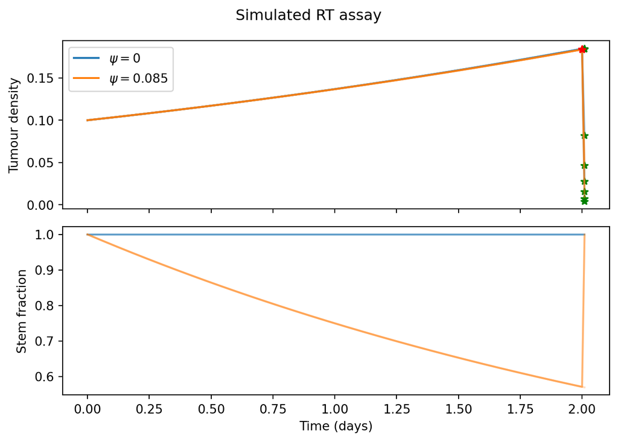

```python
fig, axs = plt.subplots(2, sharex=True)
w = 0
BMP4_colors = list(mcolors.TABLEAU_COLORS)
for ipsi in range(npsi) :
    for j in range(nRT):

        axs[1].plot(t,1 - VS_all[w]/N_all[w], psi_colors[ipsi], alpha=0.25)
        axs[0].plot(t,N_all[w],psi_colors[ipsi], alpha = 0.5)

        axs[0].plot(RT_pre_t[j,ipsi],RT_pre_size[j,ipsi],'r*',label='_nolegend_')
        axs[0].plot(RT_post_t[j,ipsi],RT_post_size[j,ipsi],'g*',label='_nolegend_')

        w = w + 1

axs[1].set(xlabel="Time (days)")
axs[1].set(ylabel="Stem fraction")
axs[0].set(ylabel="Tumour density")
fig.suptitle("Simulated RT assay")
leg = axs[0].legend([r"$\psi = 0$", fr"$\psi = {psi_values[1]:.3g}$"], loc='upper left')
leg.legend_handles[0].set_color('tab:blue')
leg.legend_handles[1].set_color('tab:orange')
#leg.legend_handles[2].set_color('tab:green')
#leg.legend_handles[3].set_color('tab:red')
#leg.legend_handles[4].set_color('tab:purple')
leg.legend_handles[0].set_alpha(1)
leg.legend_handles[1].set_alpha(1)
#leg.legend_handles[2].set_alpha(1)
#leg.legend_handles[3].set_alpha(1)
#leg.legend_handles[4].set_alpha(1)
plt.tight_layout()
plt.savefig("png/simulated_RT_assay_GBM1a.png")
plt.savefig("svg/simulated_RT_assay_GBM1a.svg")
plt.show()
```

Plot with the real data.

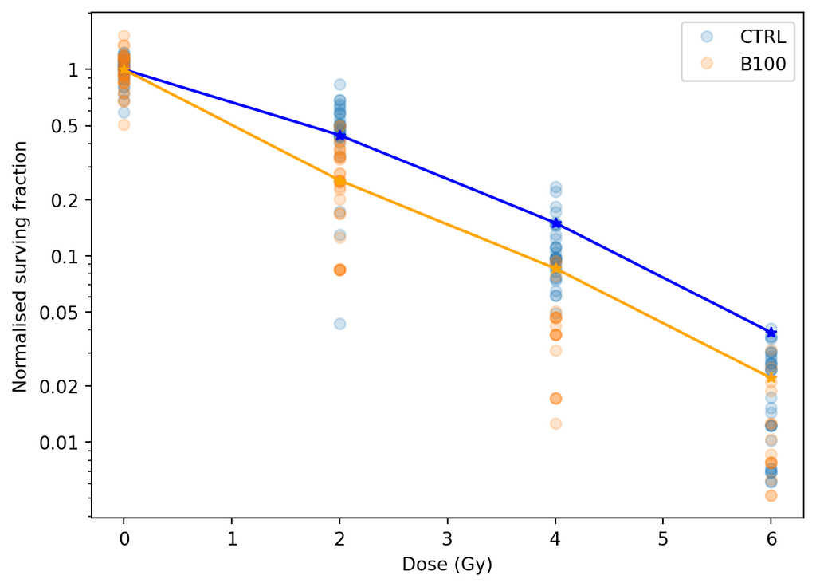

```python
# plot the data
plt.figure()
plt.plot(rt_df[(rt_df["cline"] == cline) & (rt_df["group"] == "CTRL")]["dose"],rt_df[(rt_df["cline"]== cline) & (rt_df["group"] == "CTRL")]["norm_pe"] , 'o',alpha = 0.2)
plt.plot(rt_df[(rt_df["cline"] == cline) & (rt_df["group"] == "BMP4")]["dose"],rt_df[(rt_df["cline"]== cline) & (rt_df["group"] == "BMP4")]["norm_pe"] , 'o',alpha = 0.2)

RT_to_plot = RT_post_size/RT_post_size[0,:]
#plt.plot(RT_doses,RT_post_size/RT_post_size[0,:],'-*')
plt.plot(RT_doses, RT_to_plot[:,0],'b-*')
plt.plot(RT_doses, RT_to_plot[:,1],'-*', color='orange')

plt.legend(["CTRL", "B100"])
plt.xlabel("Dose (Gy)")
plt.ylabel("Normalised surving fraction")
plt.yscale('log')
ticks = [0.01,0.02,0.05,0.1,0.2,0.5,1]
ticks_str = list(map(str, ticks)) # Convert each number to a string
plt.yticks(ticks, ticks_str)
plt.savefig("png/simulated_dose_response_GBM1a.png")
plt.savefig("svg/simulated_dose_response_GBM1a.svg")
plt.show()
```

## 4.2 QNS120

doubling time is 43.5243hrs (1.8135125days) according to this the growth should be

$$N(t) = N_0 2^{t/T}$$

```python
N = s0*2**(48/43.5243)
print("Expected size of colon after 48hrs for GMB1a")
print(N)
```

```
Expected size of colon after 48hrs for GMB1a
0.21477591389744
```

```python
cline = "QNS120"

#pro_rate = m_s_estimate.x
pro_rate = fitted_pro_rates[fitted_pro_rates["cline"] == cline]["pro_rate"].iloc[0] # value from the fit

t_final = t_rad + t_assay

# Define proliferation rates for the diffent cell pops
mv = mv_rho_scale*pro_rate*np.ones(n)
ms = ms_mv_scale*mv[0]
mv[n-1] = 0


# According to the RT data fits for QNS120 we get
#alpha = 0.014037184418926985 / eta
#beta =  0.03455851742606245 / eta

# Assuming alpha/beta = 10 fixed
alpha = 0.11569914 / eta
beta = (0.11569914/10) / eta

psi_values = [0,psi_fits[psi_fits["cline"]==cline]["Psi_10"].iloc[0]] # different values of psi used in assay

# set up time grid
t = np.arange(0, t_final+dt/2, dt)
nt = len(t)


# set up array to store model solution
u_all = []
VS_all = []
N_all = []


for ipsi in range(npsi) :
    for j in range(nRT):

        # set up array to store model solution
        u = np.zeros((nt,n+1))
        VS = np.zeros(nt)
        N = np.zeros(nt)

        # define IC
        u[0,0] = s0
        VS[0] = np.sum(u[0,1:n+1]) # sum the 1th to nth entries
        N[0] = u[0,0] + VS[0]

        i = 0
        while t[i] < t_final:
                if t[i] <= t_rad :
                    Ps = Ps_min + (Ps_max - Ps_min)*(1 / (1 + psi_values[ipsi]*BMP4_dose))
                else :
                    Ps = Ps_max

                u[i+1,:] = u[i,:] + dt * gmf.gsc_model_dudt(u[i,:],n,Ps,k,ms,mv,delta_s,delta_v)
                # apply radiation
                if t[i] == t_rad :
                    u[i+1,:] = gmf.radiation(u[i+1,:],alpha,beta,eta,mu,d=RT_doses[j])
                    RT_pre_size[j,ipsi] = np.sum(u[i,:])
                    RT_pre_t[j,ipsi] = t[i]
                    RT_post_size[j,ipsi] = np.sum(u[i+1,:])
                    RT_post_t[j,ipsi] = t[i+1]

                VS[i+1] = np.sum(u[i+1,1:n+1])
                N[i+1] = u[i+1,0] + VS[i+1]

                i = i + 1

        u_all.append(u)
        VS_all.append(VS)
        N_all.append(N)
        #print("Actuall size after 48hrs")
        #print(N[-2]) # need to print second last item as the last one has had RT applied

print("Stem cell fraction just before RT")
print(1- VS[-2]/N[-2])

print("According to DLQ stem cell fraction should be")
print(0.76976374)
```

```
Stem cell fraction just before RT
0.7704345174014111
According to DLQ stem cell fraction should be
0.76976374
```

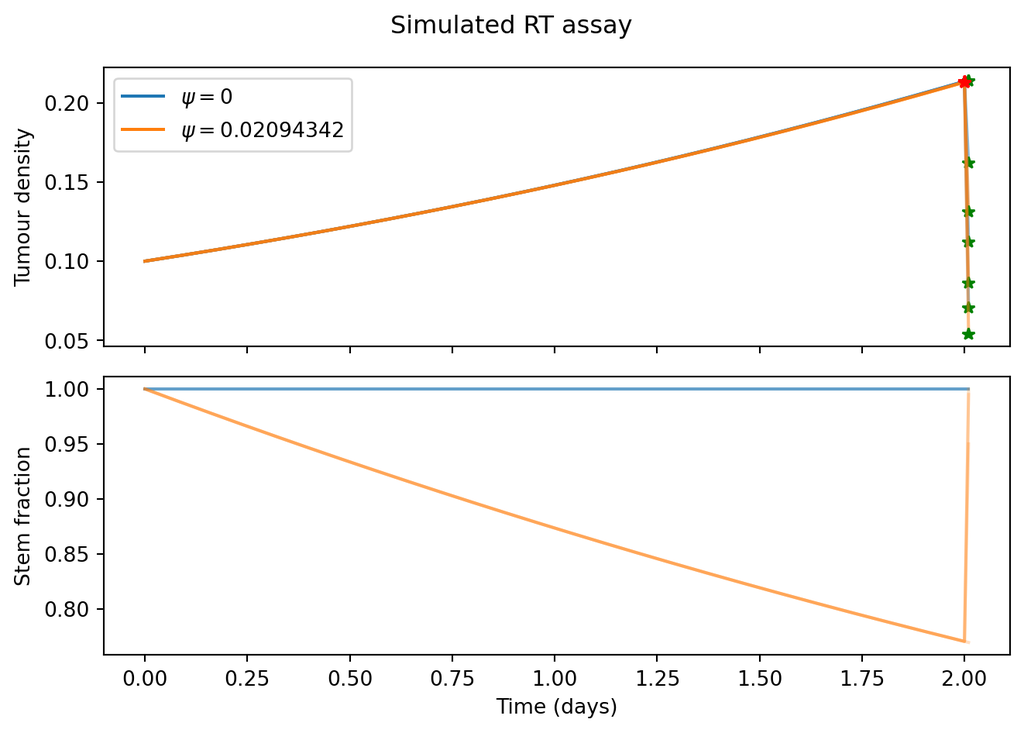

```python
fig, axs = plt.subplots(2, sharex=True)
w = 0
BMP4_colors = list(mcolors.TABLEAU_COLORS)
for ipsi in range(npsi) :
    for j in range(nRT):

        axs[1].plot(t,1 - VS_all[w]/N_all[w], psi_colors[ipsi], alpha=0.25)
        axs[0].plot(t,N_all[w],psi_colors[ipsi], alpha = 0.5)

        axs[0].plot(RT_pre_t[j,ipsi],RT_pre_size[j,ipsi],'r*',label='_nolegend_')
        axs[0].plot(RT_post_t[j,ipsi],RT_post_size[j,ipsi],'g*',label='_nolegend_')

        w = w + 1

axs[1].set(xlabel="Time (days)")
axs[1].set(ylabel="Stem fraction")
axs[0].set(ylabel="Tumour density")
fig.suptitle("Simulated RT assay")
leg = axs[0].legend([r"$\psi = 0$",fr"$\psi = {psi_values[1]}$"], loc='upper left')
leg.legend_handles[0].set_color('tab:blue')
leg.legend_handles[1].set_color('tab:orange')
#leg.legend_handles[2].set_color('tab:green')
#leg.legend_handles[3].set_color('tab:red')
#leg.legend_handles[4].set_color('tab:purple')
leg.legend_handles[0].set_alpha(1)
leg.legend_handles[1].set_alpha(1)
#leg.legend_handles[2].set_alpha(1)
#leg.legend_handles[3].set_alpha(1)
#leg.legend_handles[4].set_alpha(1)
plt.tight_layout()
#plt.savefig("../SMB_figs/simulated_RT_assay.svg")
plt.savefig("png/simulated_RT_assay_QNS120.png")
plt.savefig("svg/simulated_RT_assay_QNS120.svg")
plt.show()
```

Plot simulate assay along with real data

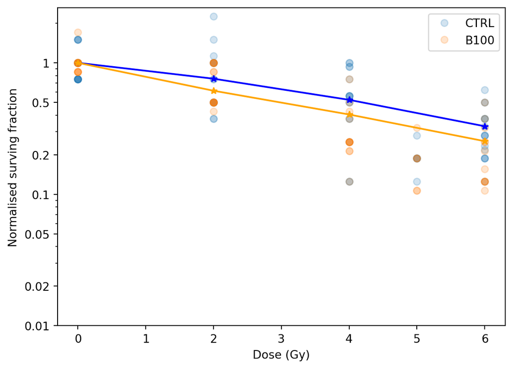

```python
# plot the data
# plot the data
plt.figure()
plt.plot(rt_df[(rt_df["cline"] == cline) & (rt_df["group"] == "CTRL")]["dose"],rt_df[(rt_df["cline"]== cline) & (rt_df["group"] == "CTRL")]["norm_pe"] , 'o',alpha = 0.2)
plt.plot(rt_df[(rt_df["cline"] == cline) & (rt_df["group"] == "BMP4")]["dose"],rt_df[(rt_df["cline"]== cline) & (rt_df["group"] == "BMP4")]["norm_pe"] , 'o',alpha = 0.2)

RT_to_plot = RT_post_size/RT_post_size[0,:]
#plt.plot(RT_doses,RT_post_size/RT_post_size[0,:],'-*')
plt.plot(RT_doses, RT_to_plot[:,0],'b-*')
plt.plot(RT_doses, RT_to_plot[:,1],'-*', color='orange')

plt.legend(["CTRL", "B100"])
plt.xlabel("Dose (Gy)")
plt.ylabel("Normalised surving fraction")
plt.yscale('log')
ticks = [0.01,0.02,0.05,0.1,0.2,0.5,1]
ticks_str = list(map(str, ticks)) # Convert each number to a string
plt.yticks(ticks, ticks_str)
plt.savefig("png/simulated_dose_response_QNS120.png")
plt.savefig("svg/simulated_dose_response_QNS120.svg")
plt.show()
```

## 4.3 QNS108

doubling time is 109.3591hrs according to this the growth should be

$$N(t) = N_0 2^{t/T}$$

```python
N = s0*2**(48/109.3591)
print("Expected size of colon after 48hrs for GMB1a")
print(N)
```

```
Expected size of colon after 48hrs for GMB1a
0.13555900469911625
```

```python
cline = "QNS108"

#pro_rate = m_s_estimate.x
pro_rate = fitted_pro_rates[fitted_pro_rates["cline"] == cline]["pro_rate"].iloc[0] # value from the fit

t_final = t_rad + t_assay

# Define proliferation rates for the diffent cell pops
mv = mv_rho_scale*pro_rate*np.ones(n)
ms = ms_mv_scale*mv[0]
mv[n-1] = 0


# According to the RT data fits for QNS120 we get
#alpha = 0.2175843971485717 / eta
#beta =  8.702061194838374e-15 / eta

# Assuming alpha/beta = 10 fixed
alpha = 0.15131625 / eta
beta = (0.15131625/10) / eta

psi_values = [0,psi_fits[psi_fits["cline"]==cline]["Psi_10"].iloc[0]] # different values of psi used in assay

# set up time grid
t = np.arange(0, t_final+dt/2, dt)
nt = len(t)


# set up array to store model solution
u_all = []
VS_all = []
N_all = []


for ipsi in range(npsi) :
    for j in range(nRT):

        # set up array to store model solution
        u = np.zeros((nt,n+1))
        VS = np.zeros(nt)
        N = np.zeros(nt)

        # define IC
        u[0,0] = s0
        VS[0] = np.sum(u[0,1:n+1]) # sum the 1th to nth entries
        N[0] = u[0,0] + VS[0]

        i = 0
        while t[i] < t_final:
                if t[i] <= t_rad :
                    Ps = Ps_min + (Ps_max - Ps_min)*(1 / (1 + psi_values[ipsi]*BMP4_dose))
                else :
                    Ps = Ps_max

                u[i+1,:] = u[i,:] + dt * gmf.gsc_model_dudt(u[i,:],n,Ps,k,ms,mv,delta_s,delta_v)
                # apply radiation
                if t[i] == t_rad :
                    u[i+1,:] = gmf.radiation(u[i+1,:],alpha,beta,eta,mu,d=RT_doses[j])
                    RT_pre_size[j,ipsi] = np.sum(u[i,:])
                    RT_pre_t[j,ipsi] = t[i]
                    RT_post_size[j,ipsi] = np.sum(u[i+1,:])
                    RT_post_t[j,ipsi] = t[i+1]

                VS[i+1] = np.sum(u[i+1,1:n+1])
                N[i+1] = u[i+1,0] + VS[i+1]

                i = i + 1

        u_all.append(u)
        VS_all.append(VS)
        N_all.append(N)
        #print("Actuall size after 48hrs")
        #print(N[-2]) # need to print second last item as the last one has had RT applied

print("Stem cell fraction just before RT")
print(1- VS[-2]/N[-2])

print("According to DLQ stem cell fraction should be")
print(0.97809831)
```

```
Stem cell fraction just before RT
0.9487350337702278
According to DLQ stem cell fraction should be
0.97809831
```

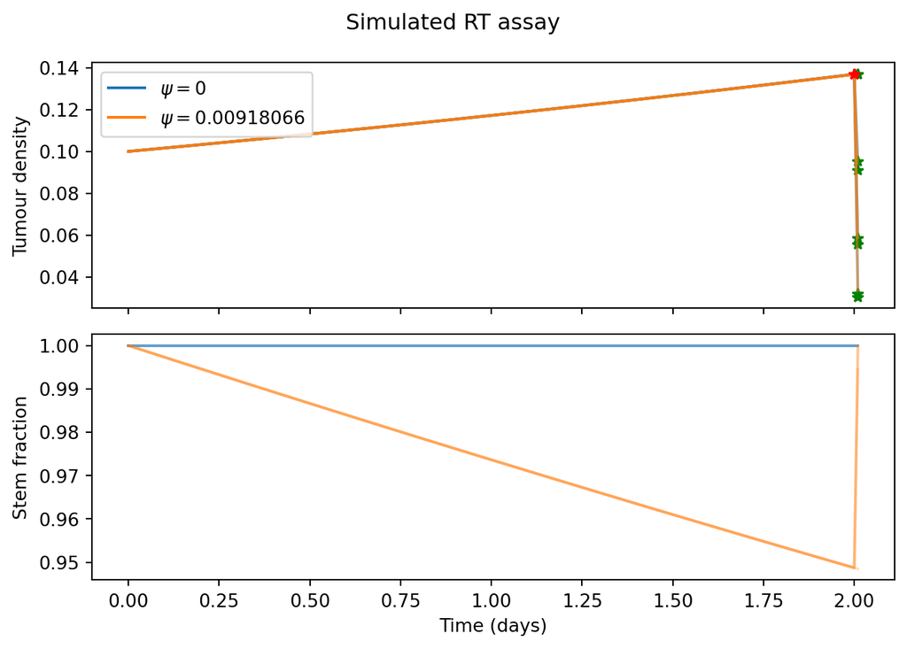

```python
fig, axs = plt.subplots(2, sharex=True)
w = 0
BMP4_colors = list(mcolors.TABLEAU_COLORS)
for ipsi in range(npsi) :
    for j in range(nRT):

        axs[1].plot(t,1 - VS_all[w]/N_all[w], psi_colors[ipsi], alpha=0.25)
        axs[0].plot(t,N_all[w],psi_colors[ipsi], alpha = 0.5)

        axs[0].plot(RT_pre_t[j,ipsi],RT_pre_size[j,ipsi],'r*',label='_nolegend_')
        axs[0].plot(RT_post_t[j,ipsi],RT_post_size[j,ipsi],'g*',label='_nolegend_')

        w = w + 1

axs[1].set(xlabel="Time (days)")
axs[1].set(ylabel="Stem fraction")
axs[0].set(ylabel="Tumour density")
fig.suptitle("Simulated RT assay")
leg = axs[0].legend([r"$\psi = 0$",fr"$\psi = {psi_values[1]}$"], loc='upper left')
leg.legend_handles[0].set_color('tab:blue')
leg.legend_handles[1].set_color('tab:orange')
#leg.legend_handles[2].set_color('tab:green')
#leg.legend_handles[3].set_color('tab:red')
#leg.legend_handles[4].set_color('tab:purple')
leg.legend_handles[0].set_alpha(1)
leg.legend_handles[1].set_alpha(1)
#leg.legend_handles[2].set_alpha(1)
#leg.legend_handles[3].set_alpha(1)
#leg.legend_handles[4].set_alpha(1)
plt.tight_layout()
#plt.savefig("../SMB_figs/simulated_RT_assay.svg")
plt.savefig("png/simulated_RT_assay_QNS108.png")
plt.savefig("svg/simulated_RT_assay_QNS108.svg")
plt.show()
```

Plot simulate assay along with real data

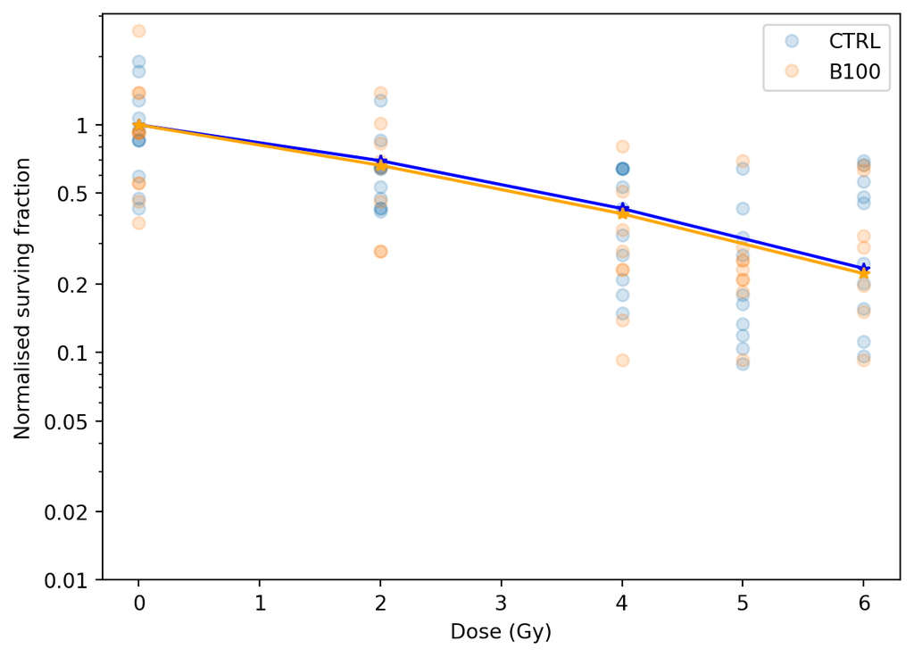

```python
# plot the data
# plot the data
plt.figure()
plt.plot(rt_df[(rt_df["cline"] == cline) & (rt_df["group"] == "CTRL")]["dose"],rt_df[(rt_df["cline"]== cline) & (rt_df["group"] == "CTRL")]["norm_pe"] , 'o',alpha = 0.2)
plt.plot(rt_df[(rt_df["cline"] == cline) & (rt_df["group"] == "BMP4")]["dose"],rt_df[(rt_df["cline"]== cline) & (rt_df["group"] == "BMP4")]["norm_pe"] , 'o',alpha = 0.2)

RT_to_plot = RT_post_size/RT_post_size[0,:]
#plt.plot(RT_doses,RT_post_size/RT_post_size[0,:],'-*')
plt.plot(RT_doses, RT_to_plot[:,0],'b-*')
plt.plot(RT_doses, RT_to_plot[:,1],'-*', color='orange')

plt.legend(["CTRL", "B100"])
plt.xlabel("Dose (Gy)")
plt.ylabel("Normalised surving fraction")
plt.yscale('log')
ticks = [0.01,0.02,0.05,0.1,0.2,0.5,1]
ticks_str = list(map(str, ticks)) # Convert each number to a string
plt.yticks(ticks, ticks_str)
plt.savefig("png/simulated_dose_response_QNS108.png")
plt.savefig("svg/simulated_dose_response_QNS108.svg")
plt.show()
```

## 4.4 QNS315

doubling time is 63.61046hrs according to this the growth should be

$$N(t) = N_0 2^{t/T}$$

```python
N = s0*2**(48/63.61046)
print("Expected size of colon after 48hrs for GMB1a")
print(N)
```

```
Expected size of colon after 48hrs for GMB1a
0.16871554159529
```

```python
cline = "QNS315"

#pro_rate = m_s_estimate.x
pro_rate = fitted_pro_rates[fitted_pro_rates["cline"] == cline]["pro_rate"].iloc[0] # value from the fit

t_final = t_rad + t_assay

# Define proliferation rates for the diffent cell pops
mv = mv_rho_scale*pro_rate*np.ones(n)
ms = ms_mv_scale*mv[0]
mv[n-1] = 0


# According to the RT data fits for QNS120 we get
#alpha = 8.633812961320722e-15 / eta
#beta =  0.027575866247915973 / eta

# Assuming alpha/beta = 10 fixed
alpha = 0.0841315 / eta
beta = (0.0841315/10) / eta

psi_values = [0,psi_fits[psi_fits["cline"]==cline]["Psi_10"].iloc[0]] # different values of psi used in assay

# set up time grid
t = np.arange(0, t_final+dt/2, dt)
nt = len(t)


# set up array to store model solution
u_all = []
VS_all = []
N_all = []


for ipsi in range(npsi) :
    for j in range(nRT):

        # set up array to store model solution
        u = np.zeros((nt,n+1))
        VS = np.zeros(nt)
        N = np.zeros(nt)

        # define IC
        u[0,0] = s0
        VS[0] = np.sum(u[0,1:n+1]) # sum the 1th to nth entries
        N[0] = u[0,0] + VS[0]

        i = 0
        while t[i] < t_final:
                if t[i] <= t_rad :
                    Ps = Ps_min + (Ps_max - Ps_min)*(1 / (1 + psi_values[ipsi]*BMP4_dose))
                else :
                    Ps = Ps_max

                u[i+1,:] = u[i,:] + dt * gmf.gsc_model_dudt(u[i,:],n,Ps,k,ms,mv,delta_s,delta_v)
                # apply radiation
                if t[i] == t_rad :
                    u[i+1,:] = gmf.radiation(u[i+1,:],alpha,beta,eta,mu,d=RT_doses[j])
                    RT_pre_size[j,ipsi] = np.sum(u[i,:])
                    RT_pre_t[j,ipsi] = t[i]
                    RT_post_size[j,ipsi] = np.sum(u[i+1,:])
                    RT_post_t[j,ipsi] = t[i+1]

                VS[i+1] = np.sum(u[i+1,1:n+1])
                N[i+1] = u[i+1,0] + VS[i+1]

                i = i + 1

        u_all.append(u)
        VS_all.append(VS)
        N_all.append(N)
        #print("Actuall size after 48hrs")
        #print(N[-2]) # need to print second last item as the last one has had RT applied

print("Stem cell fraction just before RT")
print(1- VS[-2]/N[-2])

print("According to DLQ stem cell fraction should be")
print(1)
```

```
Stem cell fraction just before RT
1.0
According to DLQ stem cell fraction should be
1
```

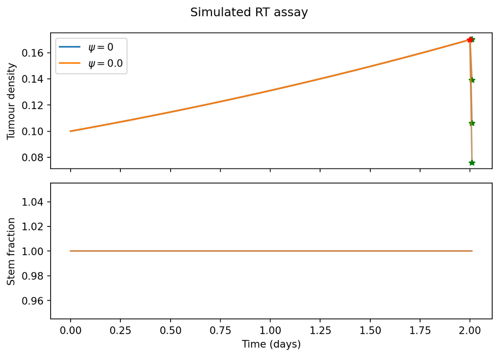

```python
fig, axs = plt.subplots(2, sharex=True)
w = 0
BMP4_colors = list(mcolors.TABLEAU_COLORS)
for ipsi in range(npsi) :
    for j in range(nRT):

        axs[1].plot(t,1 - VS_all[w]/N_all[w], psi_colors[ipsi], alpha=0.25)
        axs[0].plot(t,N_all[w],psi_colors[ipsi], alpha = 0.5)

        axs[0].plot(RT_pre_t[j,ipsi],RT_pre_size[j,ipsi],'r*',label='_nolegend_')
        axs[0].plot(RT_post_t[j,ipsi],RT_post_size[j,ipsi],'g*',label='_nolegend_')

        w = w + 1

axs[1].set(xlabel="Time (days)")
axs[1].set(ylabel="Stem fraction")
axs[0].set(ylabel="Tumour density")
fig.suptitle("Simulated RT assay")
leg = axs[0].legend([r"$\psi = 0$",fr"$\psi = {psi_values[1]}$"], loc='upper left')
leg.legend_handles[0].set_color('tab:blue')
leg.legend_handles[1].set_color('tab:orange')
#leg.legend_handles[2].set_color('tab:green')
#leg.legend_handles[3].set_color('tab:red')
#leg.legend_handles[4].set_color('tab:purple')
leg.legend_handles[0].set_alpha(1)
leg.legend_handles[1].set_alpha(1)
#leg.legend_handles[2].set_alpha(1)
#leg.legend_handles[3].set_alpha(1)
#leg.legend_handles[4].set_alpha(1)
plt.tight_layout()
#plt.savefig("../SMB_figs/simulated_RT_assay.svg")
plt.savefig("png/simulated_RT_assay_QNS315.png")
plt.savefig("svg/simulated_RT_assay_QNS315.svg")
plt.show()
```

Plot simulate assay along with real data

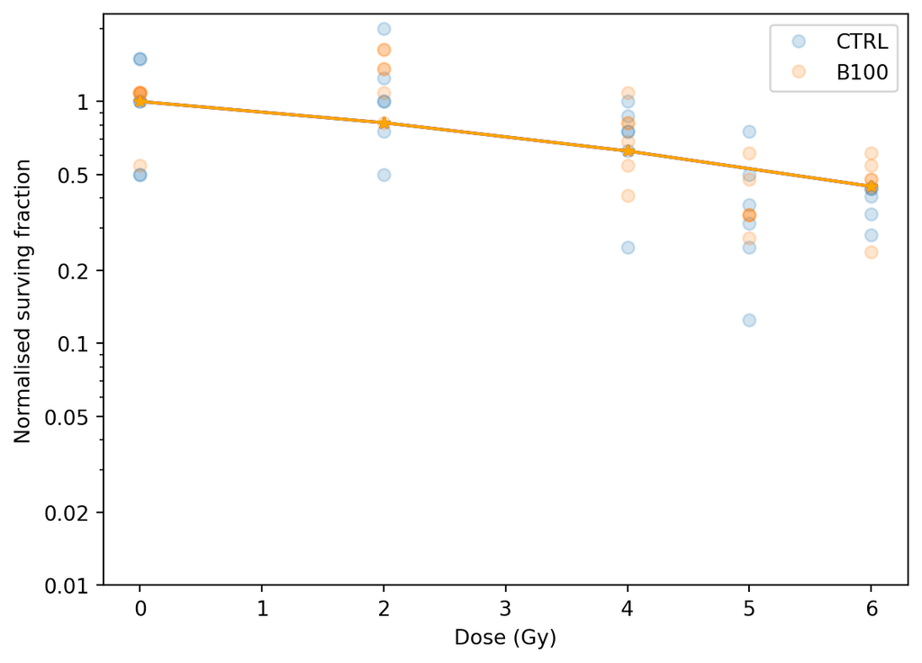

```python
# plot the data
# plot the data
plt.figure()
plt.plot(rt_df[(rt_df["cline"] == cline) & (rt_df["group"] == "CTRL")]["dose"],rt_df[(rt_df["cline"]== cline) & (rt_df["group"] == "CTRL")]["norm_pe"] , 'o',alpha = 0.2)
plt.plot(rt_df[(rt_df["cline"] == cline) & (rt_df["group"] == "BMP4")]["dose"],rt_df[(rt_df["cline"]== cline) & (rt_df["group"] == "BMP4")]["norm_pe"] , 'o',alpha = 0.2)

RT_to_plot = RT_post_size/RT_post_size[0,:]
#plt.plot(RT_doses,RT_post_size/RT_post_size[0,:],'-*')
plt.plot(RT_doses, RT_to_plot[:,0],'b-*')
plt.plot(RT_doses, RT_to_plot[:,1],'-*', color='orange')

plt.legend(["CTRL", "B100"])
plt.xlabel("Dose (Gy)")
plt.ylabel("Normalised surving fraction")
plt.yscale('log')
ticks = [0.01,0.02,0.05,0.1,0.2,0.5,1]
ticks_str = list(map(str, ticks)) # Convert each number to a string
plt.yticks(ticks, ticks_str)
plt.savefig("png/simulated_dose_response_QNS315.png")
plt.savefig("svg/simulated_dose_response_QNS315.svg")
plt.show()
```

## 4.5 QNS657

doubling time is 75.63042hrs according to this the growth should be

$$N(t) = N_0 2^{t/T}$$

```python
N = s0*2**(48/75.63042)
print("Expected size of colon after 48hrs for GMB1a")
print(N)
```

```
Expected size of colon after 48hrs for GMB1a
0.15525774703715933
```

```python
cline = "QNS657"

#pro_rate = m_s_estimate.x
pro_rate = fitted_pro_rates[fitted_pro_rates["cline"] == cline]["pro_rate"].iloc[0] # value from the fit

t_final = t_rad + t_assay

# Define proliferation rates for the diffent cell pops
mv = mv_rho_scale*pro_rate*np.ones(n)
ms = ms_mv_scale*mv[0]
mv[n-1] = 0


# According to the RT data fits for QNS120 we get
#alpha = 0.06416341211391817 / eta
#beta =  0.019133324269813796 / eta

# Assuming alpha/beta = 10 fixed
alpha = 0.10378728 / eta
beta = (0.10378728/10) / eta

psi_values = [0,psi_fits[psi_fits["cline"]==cline]["Psi_10"].iloc[0]] # different values of psi used in assay

# set up time grid
t = np.arange(0, t_final+dt/2, dt)
nt = len(t)


# set up array to store model solution
u_all = []
VS_all = []
N_all = []


for ipsi in range(npsi) :
    for j in range(nRT):

        # set up array to store model solution
        u = np.zeros((nt,n+1))
        VS = np.zeros(nt)
        N = np.zeros(nt)

        # define IC
        u[0,0] = s0
        VS[0] = np.sum(u[0,1:n+1]) # sum the 1th to nth entries
        N[0] = u[0,0] + VS[0]

        i = 0
        while t[i] < t_final:
                if t[i] <= t_rad :
                    Ps = Ps_min + (Ps_max - Ps_min)*(1 / (1 + psi_values[ipsi]*BMP4_dose))
                else :
                    Ps = Ps_max

                u[i+1,:] = u[i,:] + dt * gmf.gsc_model_dudt(u[i,:],n,Ps,k,ms,mv,delta_s,delta_v)
                # apply radiation
                if t[i] == t_rad :
                    u[i+1,:] = gmf.radiation(u[i+1,:],alpha,beta,eta,mu,d=RT_doses[j])
                    RT_pre_size[j,ipsi] = np.sum(u[i,:])
                    RT_pre_t[j,ipsi] = t[i]
                    RT_post_size[j,ipsi] = np.sum(u[i+1,:])
                    RT_post_t[j,ipsi] = t[i+1]

                VS[i+1] = np.sum(u[i+1,1:n+1])
                N[i+1] = u[i+1,0] + VS[i+1]

                i = i + 1

        u_all.append(u)
        VS_all.append(VS)
        N_all.append(N)
        #print("Actuall size after 48hrs")
        #print(N[-2]) # need to print second last item as the last one has had RT applied

print("Stem cell fraction just before RT")
print(1- VS[-2]/N[-2])

print("According to DLQ stem cell fraction should be")
print(0.6823287)
```

```
Stem cell fraction just before RT
0.7067839232172803
According to DLQ stem cell fraction should be
0.6823287
```

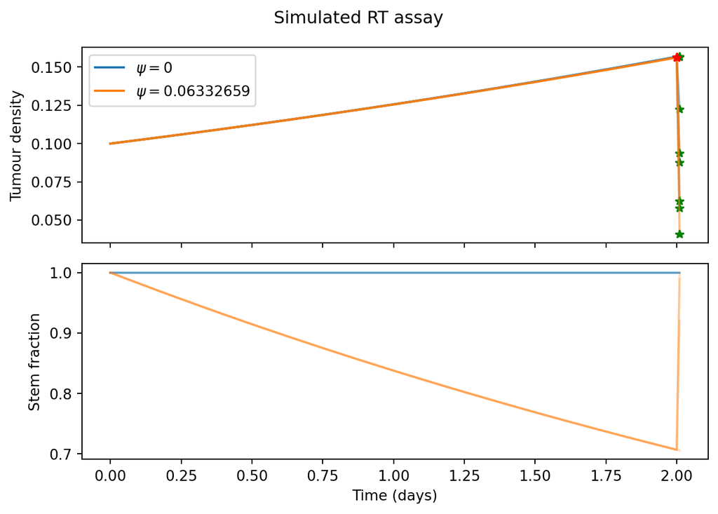

```python
fig, axs = plt.subplots(2, sharex=True)
w = 0
BMP4_colors = list(mcolors.TABLEAU_COLORS)
for ipsi in range(npsi) :
    for j in range(nRT):

        axs[1].plot(t,1 - VS_all[w]/N_all[w], psi_colors[ipsi], alpha=0.25)
        axs[0].plot(t,N_all[w],psi_colors[ipsi], alpha = 0.5)

        axs[0].plot(RT_pre_t[j,ipsi],RT_pre_size[j,ipsi],'r*',label='_nolegend_')
        axs[0].plot(RT_post_t[j,ipsi],RT_post_size[j,ipsi],'g*',label='_nolegend_')

        w = w + 1

axs[1].set(xlabel="Time (days)")
axs[1].set(ylabel="Stem fraction")
axs[0].set(ylabel="Tumour density")
fig.suptitle("Simulated RT assay")
leg = axs[0].legend([r"$\psi = 0$",fr"$\psi = {psi_values[1]}$"], loc='upper left')
leg.legend_handles[0].set_color('tab:blue')
leg.legend_handles[1].set_color('tab:orange')
#leg.legend_handles[2].set_color('tab:green')
#leg.legend_handles[3].set_color('tab:red')
#leg.legend_handles[4].set_color('tab:purple')
leg.legend_handles[0].set_alpha(1)
leg.legend_handles[1].set_alpha(1)
#leg.legend_handles[2].set_alpha(1)
#leg.legend_handles[3].set_alpha(1)
#leg.legend_handles[4].set_alpha(1)
plt.tight_layout()
#plt.savefig("../SMB_figs/simulated_RT_assay.svg")
plt.savefig("png/simulated_RT_assay_QNS657.png")
plt.savefig("svg/simulated_RT_assay_QNS657.svg")
plt.show()
```

Plot simulate assay along with real data

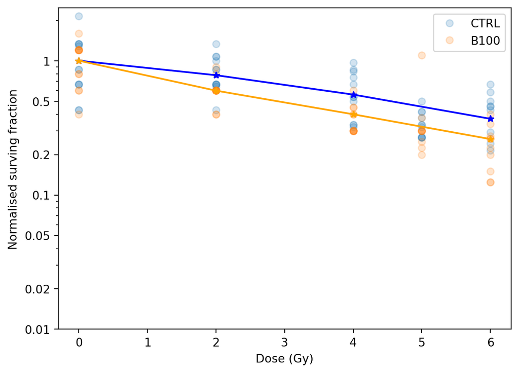

```python
# plot the data
# plot the data
plt.figure()
plt.plot(rt_df[(rt_df["cline"] == cline) & (rt_df["group"] == "CTRL")]["dose"],rt_df[(rt_df["cline"]== cline) & (rt_df["group"] == "CTRL")]["norm_pe"] , 'o',alpha = 0.2)
plt.plot(rt_df[(rt_df["cline"] == cline) & (rt_df["group"] == "BMP4")]["dose"],rt_df[(rt_df["cline"]== cline) & (rt_df["group"] == "BMP4")]["norm_pe"] , 'o',alpha = 0.2)

RT_to_plot = RT_post_size/RT_post_size[0,:]
#plt.plot(RT_doses,RT_post_size/RT_post_size[0,:],'-*')
plt.plot(RT_doses, RT_to_plot[:,0],'b-*')
plt.plot(RT_doses, RT_to_plot[:,1],'-*', color='orange')

plt.legend(["CTRL", "B100"])
plt.xlabel("Dose (Gy)")
plt.ylabel("Normalised surving fraction")
plt.yscale('log')
ticks = [0.01,0.02,0.05,0.1,0.2,0.5,1]
ticks_str = list(map(str, ticks)) # Convert each number to a string
plt.yticks(ticks, ticks_str)
plt.savefig("png/simulated_dose_response_QNS657.png")
plt.savefig("svg/simulated_dose_response_QNS657.svg")
plt.show()
```

# 5 Visualise psi values

psi defines sensitivity to BMP4, it goes from 0,1.

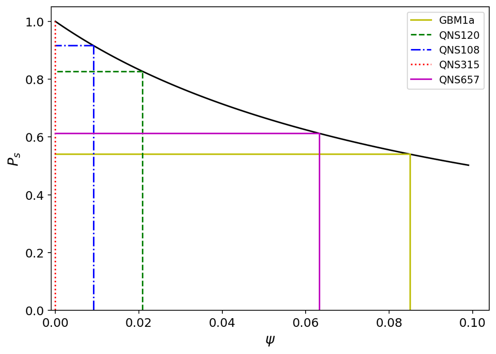

```python
# define constnts
Ps_min = 0
Ps_max = 1

# Create data points
x = np.arange(0, 0.1, 0.001)
z = Ps_min + (Ps_max - Ps_min)* 1 / (1 + x*BMP4_dose)

# Plot the curve
plt.plot(x,z,'k', label = "_nolegend_")
plt.xlabel(r"$\psi$", fontsize = 14)
plt.ylabel(r"$P_s$", fontsize = 14)
plt.xticks(fontsize = 12)
plt.yticks(fontsize = 12)

# Define line styles and colors
line_styles = ['-', '--', '-.', ':']
colors = ['y', 'g', 'b', 'r', 'm']

# Plotting
for i, cline in enumerate(psi_fits["cline"]):
    psi = psi_fits[psi_fits["cline"] == cline]["Psi_10"].iloc[0]
    # Find the corresponding y value on the curve for the given psi
    y_value = Ps_min + (Ps_max - Ps_min) * 1 / (1 + psi * BMP4_dose)
    # Plot vertical line up to the curve
    plt.plot([psi, psi], [0, y_value], linestyle=line_styles[i % len(line_styles)], color=colors[i % len(colors)], label=cline)
    # Plot horizontal line back to the left
    plt.plot([psi, 0], [y_value, y_value], linestyle=line_styles[i % len(line_styles)], color=colors[i % len(colors)])

plt.xlim(left=-0.001)
plt.ylim(bottom=0)
plt.legend()
plt.tight_layout()
plt.savefig("png/psi_values_visualised.png")
plt.savefig("svg/psi_values_visualised.svg")
plt.show()
```

For a varying BMP4 dose show the effect of psi

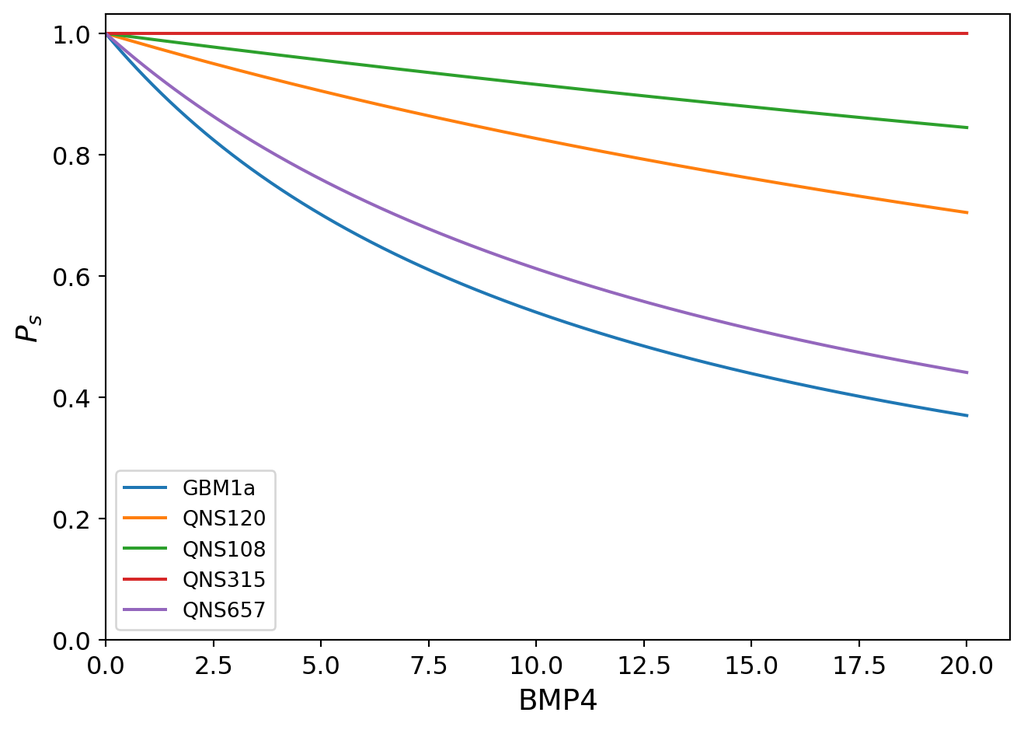

```python
# define constnts
Ps_min = 0
Ps_max = 1


# Create data points here x represents BMP4 dose.
x = np.arange(0, 20, 0.001)

# Define line styles and colors
line_styles = ['-', '--', '-.', ':']
colors = ['y', 'g', 'b', 'r', 'm']

# Plotting
for i, cline in enumerate(psi_fits["cline"]):
    psi = psi_fits[psi_fits["cline"] == cline]["Psi_10"].iloc[0]
    plt.plot(x,Ps_min + (Ps_max - Ps_min)* 1 / (1 + x*psi))

plt.xlim(left=-0.001)
plt.ylim(bottom=0)
plt.xlabel("BMP4", fontsize = 14)
plt.ylabel(r"$P_s$", fontsize = 14)
plt.xticks(fontsize = 12)
plt.yticks(fontsize = 12)
plt.legend(psi_fits["cline"])
plt.tight_layout()
plt.show()
```